# Loantap

```python
# Importing the necessary libraries

import numpy as np
import pandas as pd
import matplotlib.pyplot as plt
import seaborn as sns

import warnings
warnings.filterwarnings("ignore")
```

```python
# converting data into dataframe

loantap = pd.read_csv("logistic_regression.csv")
```

```python
# making an copy of the dataset

df = loantap.copy()
```

### Identification of variables

```python
# Top 5 rows of the dataframe

df.head()
```

|  | loan_amnt | term | int_rate | installment | grade | sub_grade | emp_title | emp_length | home_ownership | annual_inc | ... | open_acc | pub_rec | revol_bal | revol_util | total_acc | initial_list_status | application_type | mort_acc | pub_rec_bankruptcies | address |
| --- | --- | --- | --- | --- | --- | --- | --- | --- | --- | --- | --- | --- | --- | --- | --- | --- | --- | --- | --- | --- | --- |
| 0 | 10000.0 | 36 months | 11.44 | 329.48 | B | B4 | Marketing | 10+ years | RENT | 117000.0 | ... | 16.0 | 0.0 | 36369.0 | 41.8 | 25.0 | w | INDIVIDUAL | 0.0 | 0.0 | 0174 Michelle Gateway\r\nMendozaberg, OK 22690 |
| 1 | 8000.0 | 36 months | 11.99 | 265.68 | B | B5 | Credit analyst | 4 years | MORTGAGE | 65000.0 | ... | 17.0 | 0.0 | 20131.0 | 53.3 | 27.0 | f | INDIVIDUAL | 3.0 | 0.0 | 1076 Carney Fort Apt. 347\r\nLoganmouth, SD 05113 |
| 2 | 15600.0 | 36 months | 10.49 | 506.97 | B | B3 | Statistician | < 1 year | RENT | 43057.0 | ... | 13.0 | 0.0 | 11987.0 | 92.2 | 26.0 | f | INDIVIDUAL | 0.0 | 0.0 | 87025 Mark Dale Apt. 269\r\nNew Sabrina, WV 05113 |
| 3 | 7200.0 | 36 months | 6.49 | 220.65 | A | A2 | Client Advocate | 6 years | RENT | 54000.0 | ... | 6.0 | 0.0 | 5472.0 | 21.5 | 13.0 | f | INDIVIDUAL | 0.0 | 0.0 | 823 Reid Ford\r\nDelacruzside, MA 00813 |
| 4 | 24375.0 | 60 months | 17.27 | 609.33 | C | C5 | Destiny Management Inc. | 9 years | MORTGAGE | 55000.0 | ... | 13.0 | 0.0 | 24584.0 | 69.8 | 43.0 | f | INDIVIDUAL | 1.0 | 0.0 | 679 Luna Roads\r\nGreggshire, VA 11650 |

5 rows × 27 columns

```python
df.shape
```

```
(396030, 27)
```

```python
# data info

df.info()
```

```
<class 'pandas.core.frame.DataFrame'>
RangeIndex: 396030 entries, 0 to 396029
Data columns (total 27 columns):
 #   Column                Non-Null Count   Dtype
---  ------                --------------   -----
 0   loan_amnt             396030 non-null  float64
 1   term                  396030 non-null  object
 2   int_rate              396030 non-null  float64
 3   installment           396030 non-null  float64
 4   grade                 396030 non-null  object
 5   sub_grade             396030 non-null  object
 6   emp_title             373103 non-null  object
 7   emp_length            377729 non-null  object
 8   home_ownership        396030 non-null  object
 9   annual_inc            396030 non-null  float64
```

[output cut: 19 more lines]

```python
# Checking of null values

df.isna().sum()
```

```
loan_amnt                   0
term                        0
int_rate                    0
installment                 0
grade                       0
sub_grade                   0
emp_title               22927
emp_length              18301
home_ownership              0
annual_inc                  0
verification_status         0
issue_d                     0
loan_status                 0
purpose                     0
title                    1756
dti                         0
earliest_cr_line            0
open_acc                    0
pub_rec                     0
revol_bal                   0
revol_util                276
total_acc                   0
initial_list_status         0
application_type            0
mort_acc                37795
pub_rec_bankruptcies      535
address                     0
dtype: int64
```

```python
# Percentage of null values in each columns

df.isna().sum()/len(df)*100
```

```
loan_amnt               0.000000
term                    0.000000
int_rate                0.000000
installment             0.000000
grade                   0.000000
sub_grade               0.000000
emp_title               5.789208
emp_length              4.621115
home_ownership          0.000000
annual_inc              0.000000
verification_status     0.000000
issue_d                 0.000000
loan_status             0.000000
purpose                 0.000000
title                   0.443401
dti                     0.000000
earliest_cr_line        0.000000
open_acc                0.000000
pub_rec                 0.000000
revol_bal               0.000000
revol_util              0.069692
total_acc               0.000000
initial_list_status     0.000000
application_type        0.000000
mort_acc                9.543469
pub_rec_bankruptcies    0.135091
address                 0.000000
dtype: float64
```

### Analysing the basic metrics

```python
df.describe(include='all').transpose()
```

|  | count | unique | top | freq | mean | std | min | 25% | 50% | 75% | max |
| --- | --- | --- | --- | --- | --- | --- | --- | --- | --- | --- | --- |
| loan_amnt | 396030.0 | NaN | NaN | NaN | 14113.888089 | 8357.441341 | 500.0 | 8000.0 | 12000.0 | 20000.0 | 40000.0 |
| term | 396030 | 2 | 36 months | 302005 | NaN | NaN | NaN | NaN | NaN | NaN | NaN |
| int_rate | 396030.0 | NaN | NaN | NaN | 13.6394 | 4.472157 | 5.32 | 10.49 | 13.33 | 16.49 | 30.99 |
| installment | 396030.0 | NaN | NaN | NaN | 431.849698 | 250.72779 | 16.08 | 250.33 | 375.43 | 567.3 | 1533.81 |
| grade | 396030 | 7 | B | 116018 | NaN | NaN | NaN | NaN | NaN | NaN | NaN |
| sub_grade | 396030 | 35 | B3 | 26655 | NaN | NaN | NaN | NaN | NaN | NaN | NaN |
| emp_title | 373103 | 173105 | Teacher | 4389 | NaN | NaN | NaN | NaN | NaN | NaN | NaN |
| emp_length | 377729 | 11 | 10+ years | 126041 | NaN | NaN | NaN | NaN | NaN | NaN | NaN |
| home_ownership | 396030 | 6 | MORTGAGE | 198348 | NaN | NaN | NaN | NaN | NaN | NaN | NaN |
| annual_inc | 396030.0 | NaN | NaN | NaN | 74203.175798 | 61637.621158 | 0.0 | 45000.0 | 64000.0 | 90000.0 | 8706582.0 |
| verification_status | 396030 | 3 | Verified | 139563 | NaN | NaN | NaN | NaN | NaN | NaN | NaN |
| issue_d | 396030 | 115 | Oct-2014 | 14846 | NaN | NaN | NaN | NaN | NaN | NaN | NaN |
| loan_status | 396030 | 2 | Fully Paid | 318357 | NaN | NaN | NaN | NaN | NaN | NaN | NaN |
| purpose | 396030 | 14 | debt_consolidation | 234507 | NaN | NaN | NaN | NaN | NaN | NaN | NaN |
| title | 394274 | 48816 | Debt consolidation | 152472 | NaN | NaN | NaN | NaN | NaN | NaN | NaN |
| dti | 396030.0 | NaN | NaN | NaN | 17.379514 | 18.019092 | 0.0 | 11.28 | 16.91 | 22.98 | 9999.0 |
| earliest_cr_line | 396030 | 684 | Oct-2000 | 3017 | NaN | NaN | NaN | NaN | NaN | NaN | NaN |
| open_acc | 396030.0 | NaN | NaN | NaN | 11.311153 | 5.137649 | 0.0 | 8.0 | 10.0 | 14.0 | 90.0 |
| pub_rec | 396030.0 | NaN | NaN | NaN | 0.178191 | 0.530671 | 0.0 | 0.0 | 0.0 | 0.0 | 86.0 |
| revol_bal | 396030.0 | NaN | NaN | NaN | 15844.539853 | 20591.836109 | 0.0 | 6025.0 | 11181.0 | 19620.0 | 1743266.0 |
| revol_util | 395754.0 | NaN | NaN | NaN | 53.791749 | 24.452193 | 0.0 | 35.8 | 54.8 | 72.9 | 892.3 |
| total_acc | 396030.0 | NaN | NaN | NaN | 25.414744 | 11.886991 | 2.0 | 17.0 | 24.0 | 32.0 | 151.0 |
| initial_list_status | 396030 | 2 | f | 238066 | NaN | NaN | NaN | NaN | NaN | NaN | NaN |
| application_type | 396030 | 3 | INDIVIDUAL | 395319 | NaN | NaN | NaN | NaN | NaN | NaN | NaN |
| mort_acc | 358235.0 | NaN | NaN | NaN | 1.813991 | 2.14793 | 0.0 | 0.0 | 1.0 | 3.0 | 34.0 |
| pub_rec_bankruptcies | 395495.0 | NaN | NaN | NaN | 0.121648 | 0.356174 | 0.0 | 0.0 | 0.0 | 0.0 | 8.0 |
| address | 396030 | 393700 | USCGC Smith\r\nFPO AE 70466 | 8 | NaN | NaN | NaN | NaN | NaN | NaN | NaN |

#### Insights

**Outliers:** The significant differences between mean & median in key attributes like loan amount and revolving balance indicate potential outliers.

**Loan Duration Preference:** A preference for 36-month loan terms among borrowers suggests a balance between manageable installments.

**Home Ownership Trends:** The prevalence of applicants with mortgaged homes suggests financial stability or a need for substantial, property-secured loans.

**Successful Loan Repayment:** Most loans being fully paid off reflects positively on borrowers' financial commitment, indicating effective lending criteria.

**Debt Consolidation Dominance:** The primary use of loans for debt consolidation highlights a common strategy to manage or reduce high-interest debt.

**Individual Borrowers:** The predominance of individual applicants suggests that personal loans are a major market segment.

```python
n_columns = loantap.select_dtypes('float64').columns.tolist()\

n_columns
```

```
['loan_amnt',
 'int_rate',
 'installment',
 'annual_inc',
 'dti',
 'open_acc',
 'pub_rec',
 'revol_bal',
 'revol_util',
 'total_acc',
 'mort_acc',
 'pub_rec_bankruptcies']
```

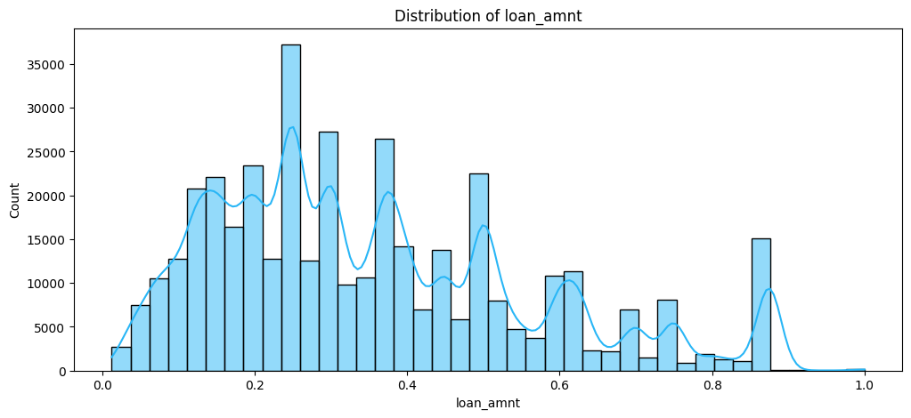

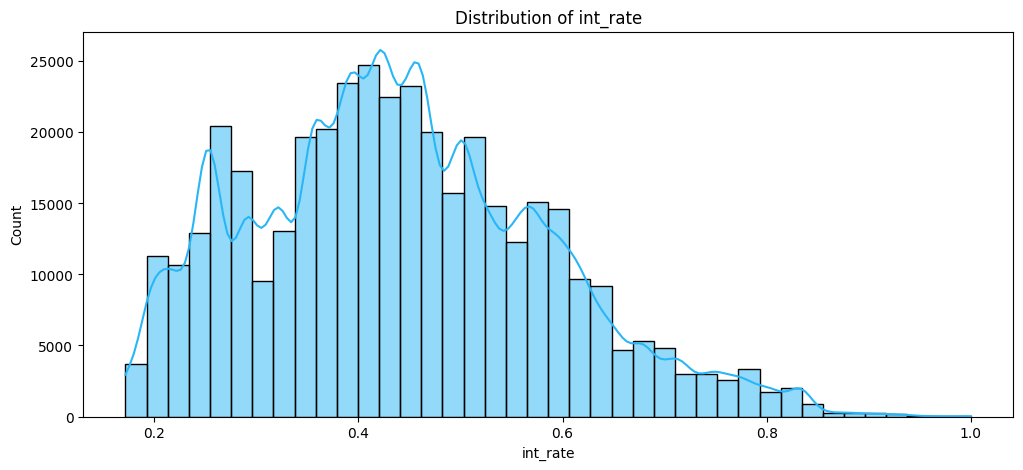

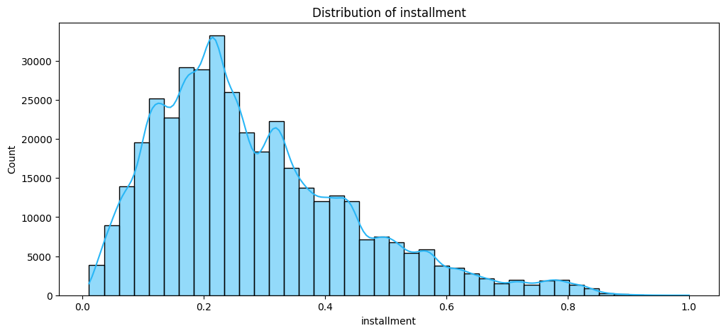

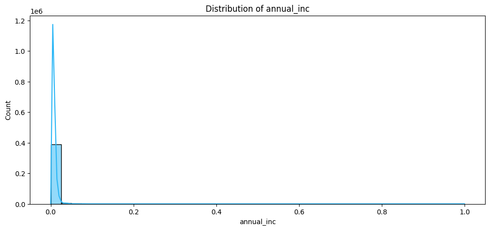

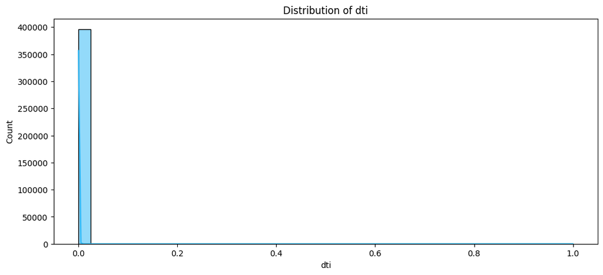

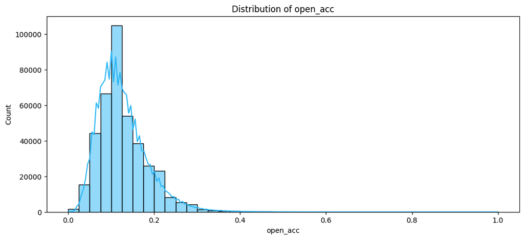

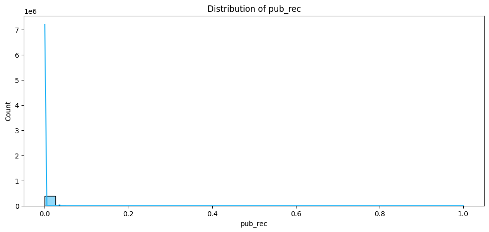

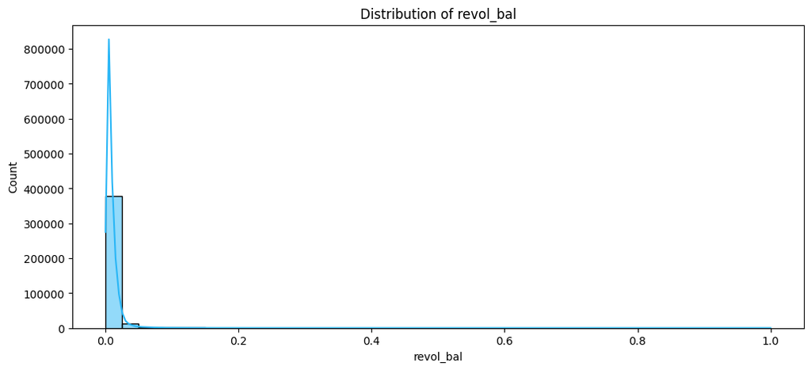

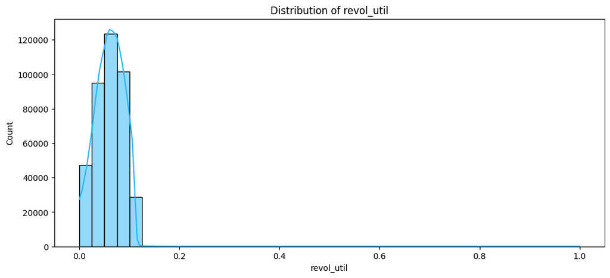

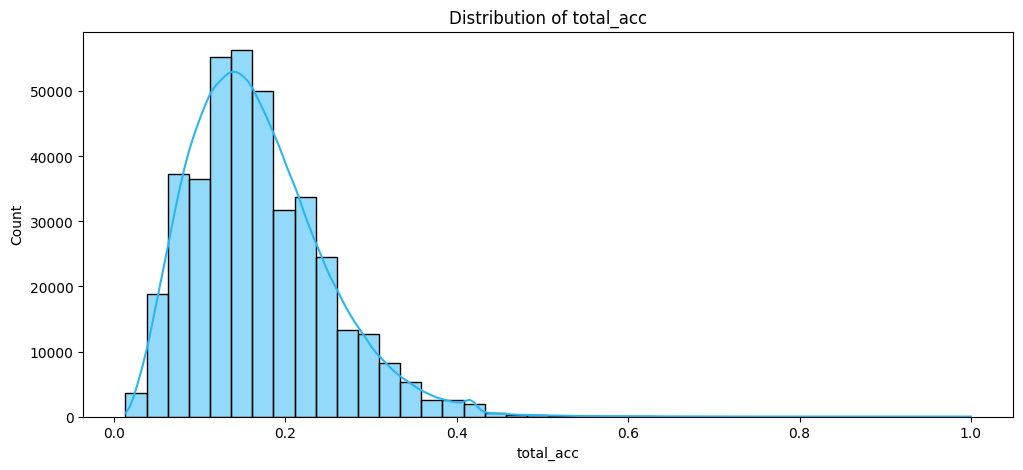

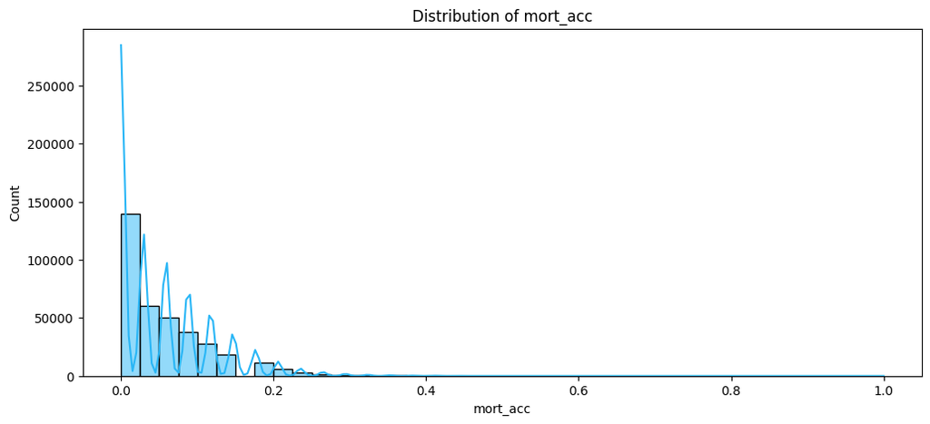

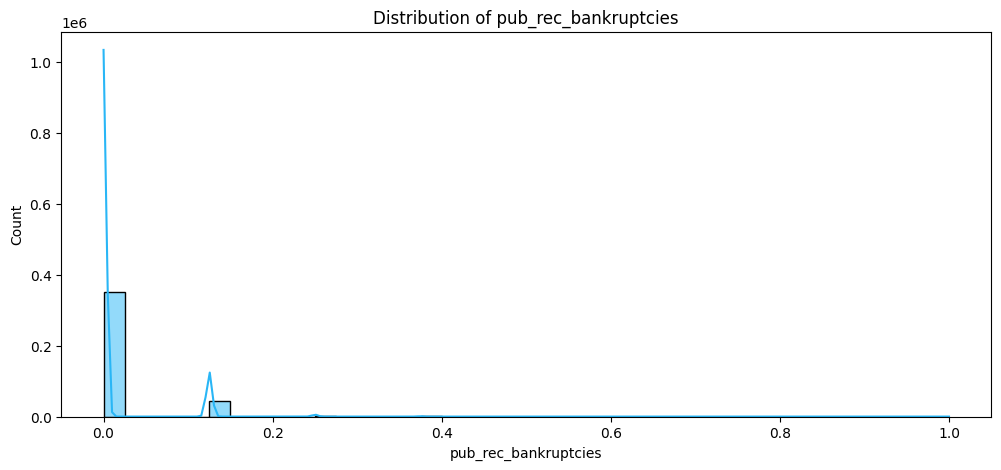

```python
for i in n_columns:
    plt.figure(figsize=(12,5))
    plt.title("Distribution of {}".format(i))
    sns.histplot(df[i]/df[i].max(), kde=True,color="#29B6F6", bins=40)
    plt.show()
```

```python
c_columns = ['home_ownership', 'verification_status', 'loan_status', 'application_type', 'grade', 'sub_grade', 'term']
```

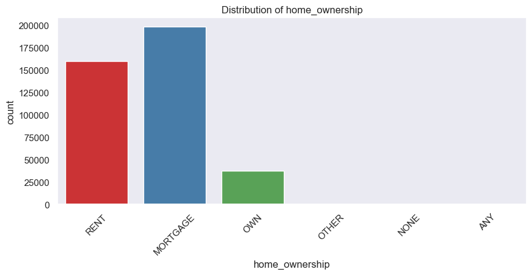

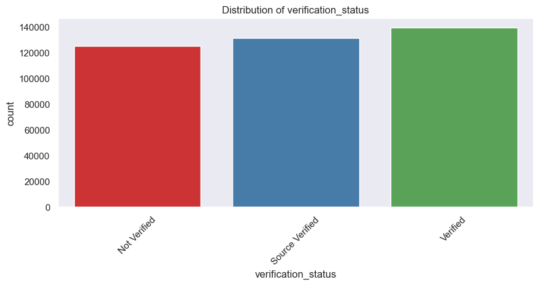

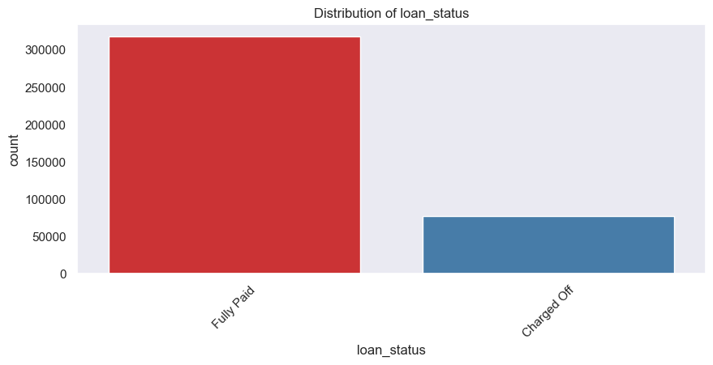

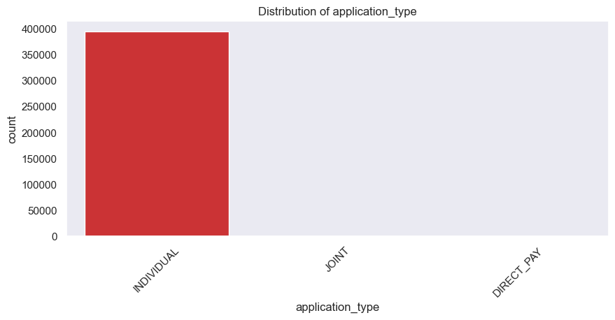

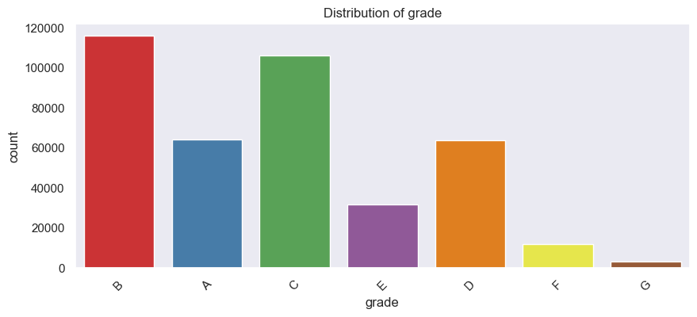

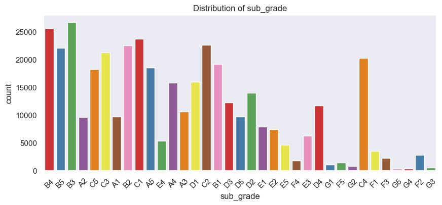

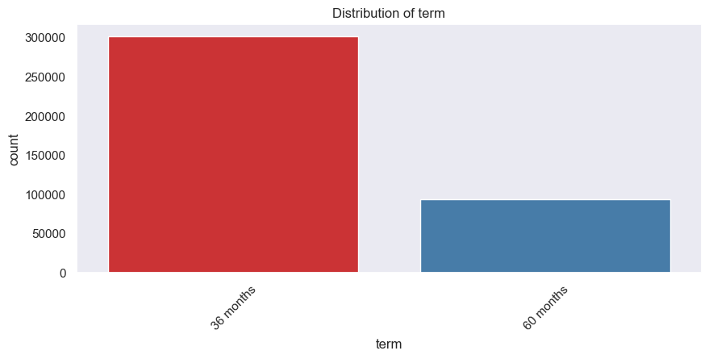

```python
custom_palette = sns.color_palette("Set1", 8)

for i in c_columns:
    plt.figure(figsize=(10, 4))
    sns.set(style="dark")
    plt.title(f'Distribution of {i}')
    sns.countplot(data=df, x=i, palette=custom_palette)
    plt.xticks(rotation=45)
    plt.show()
```